# Differential expression

2017-07-25

```r
# Run quality control template first to generate [bcbioRNADataSet]
source("setup.R")
library(DESeq2)
data(bcb) # only works if rda saved in .data

# Design formula. Uncomment with correct values.
# design <- formula(~genotype)

# Contrast. Uncomment with correct values.
# 1. Design matrix parameter.
# 2. Numerator for LFC (expt).
# 3. Denominator for LFC (control).
# @seealso [DESeq2::results()]
# contrast <- c("genotype", "mutant", "wildtype")

# Significance cutoffs
alpha <- 0.05
lfc <- 0
```

# Overview

```r
> metadata_table(bcb)
```

Sample metadata

| group |
| --- |
| ctrl |
| ctrl |
| ko |
| ko |

```r
> dds <- DESeqDataSetFromTximport(
+     txi = txi(bcb),
+     colData = colData(bcb),
+     design = design) %>%
+     DESeq
> rld <- rlog(dds)
> save_data(dds, rld, dir = data_dir)
```

# Alpha level (FDR) cutoffs

Let’s take a look at the number of genes we get with different false discovery rate (FDR) cutoffs. These tests subset *P* values that have been multiple test corrected using the Benjamini Hochberg (BH) method (Benjamini and Hochberg 1995).

```r
> alpha_summary(dds)
```

|  | 0.1 | 0.05 | 0.01 | 0.001 | 1e-06 |
| --- | --- | --- | --- | --- | --- |
| LFC > 0 (up) | 179, 0.61% | 142, 0.48% | 93, 0.32% | 58, 0.2% | 25, 0.085% |
| LFC < 0 (down) | 140, 0.48% | 104, 0.35% | 58, 0.2% | 38, 0.13% | 15, 0.051% |
| outliers | 0, 0% | 0, 0% | 0, 0% | 0, 0% | 0, 0% |
| low counts | 11599, 39% | 11046, 38% | 11046, 38% | 10494, 36% | 16570, 56% |
| cutoff | (mean count < 7) | (mean count < 6) | (mean count < 6) | (mean count < 5) | (mean count < 74) |

# Results

```r
> res_unshrunken <- results(
+     dds,
+     contrast = contrast,
+     alpha = alpha)
>
> # DESeqResults with shrunken log2 fold changes (LFC).
> # Still being prototyped, see `?lfcShrink` (DESeq 1.16).
> res_shrunken <- lfcShrink(
+     dds = dds,
+     contrast = contrast,
+     res = res_unshrunken)
>
> # Compare these two results and pick which one to report
> res <- res_shrunken
> save_data(res, res_unshrunken, res_shrunken, dir = data_dir)
```

We performed the analysis using a BH adjusted *P* value cutoff of 0.05 and a log fold-change (LFC) ratio cutoff of 0.

# Plots

## Mean average (MA)

An MA plot compares transformed counts on `M` (log ratio) and `A` (mean average) scales (Y. H. Yang et al. 2002).

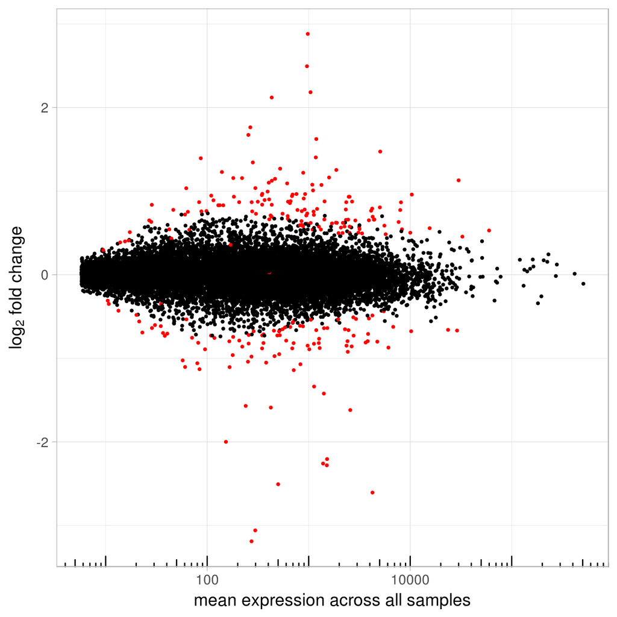

```r
> plot_ma(res)
```

## Volcano

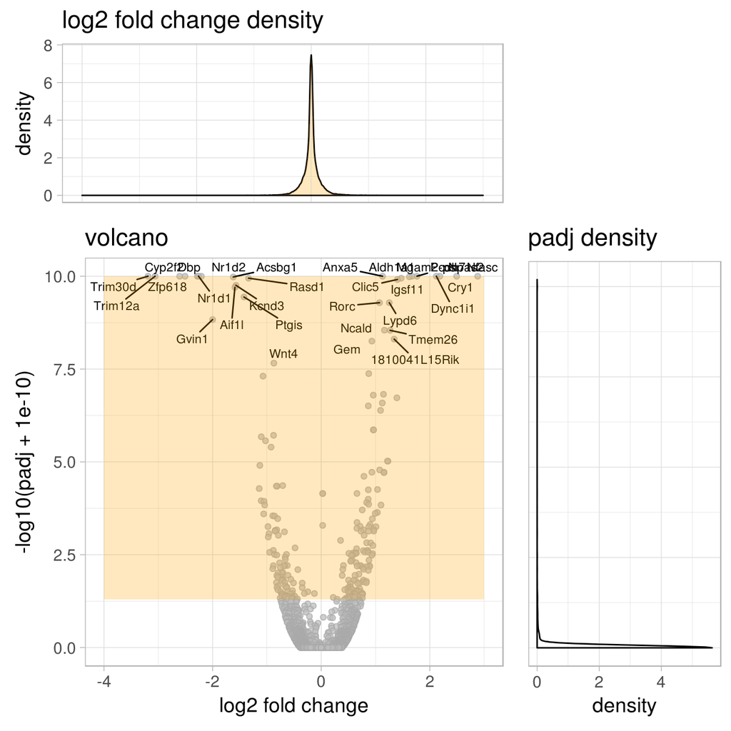

```r
> plot_volcano(bcb, res = res, lfc = lfc)
```

## Heatmap

This plot shows only differentially expressed genes on a per-sample basis. We have scaled the data by row and used the `ward.D2` method for clustering (Ward Jr 1963).

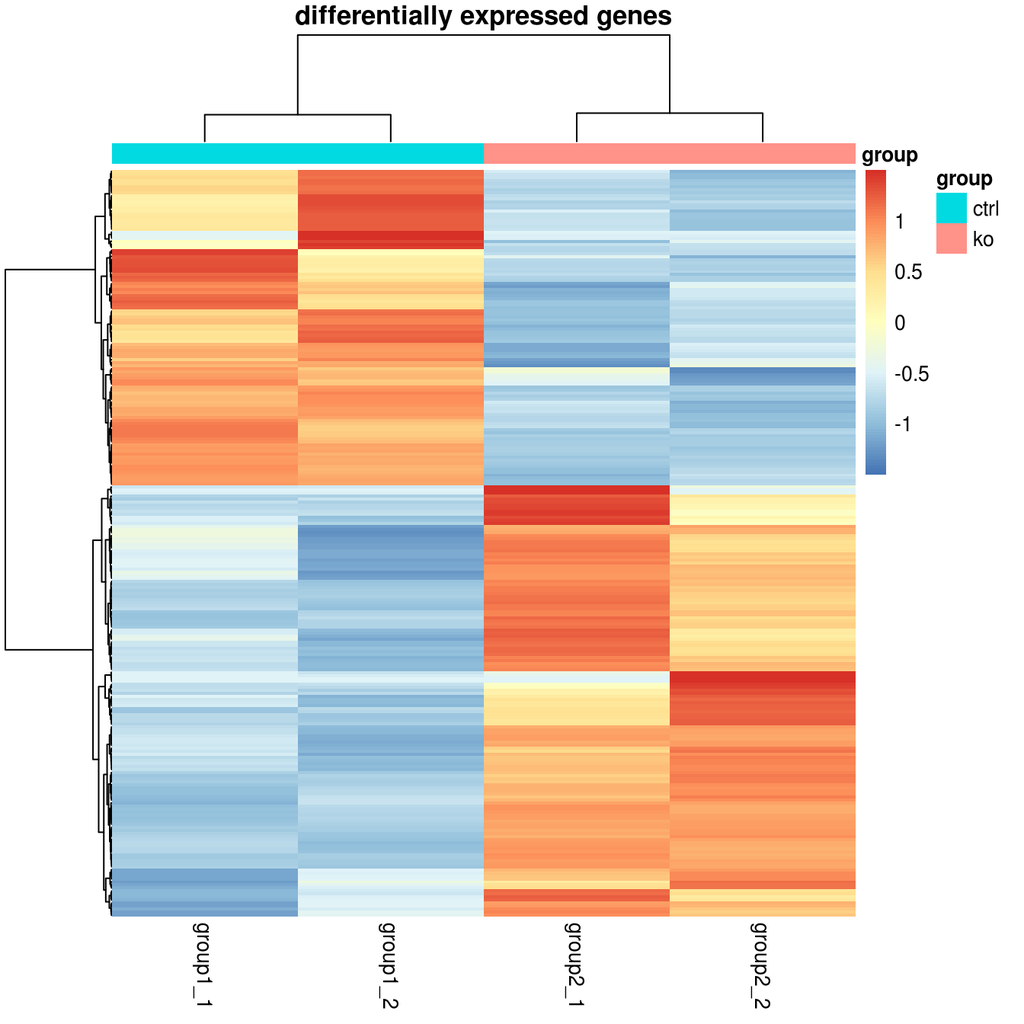

```r
> plot_deg_heatmap(bcb, res = res, lfc = lfc)
```

# File downloads

## Count matrices

- `normalized_counts.csv.gz`: Use to evaluate individual genes and/or generate plots. These counts are normalized for the variation in sequencing depth across samples.
- `tpm.csv.gz`: Transcripts per million, scaled by length and also suitable for plotting.
- `raw_counts.csv.gz`: Only use to perform a new differential expression analysis. These counts will vary across samples due to differences in sequencing depth, and have not been normalized. Do not use this file for plotting genes.

## Differentially expressed genes (DEG)

DEG tables are sorted by BH-adjusted P value, and contain the following columns:

- `ensembl_gene_id`: [Ensembl](http://useast.ensembl.org/Mus_musculus/Info/Index) gene identifier.
- `base_mean`: Mean of the normalized counts per gene for all samples.
- `log2_fold_change`: log2 fold change.
- `lfc_se`: log2 standard error.
- `stat`: Wald statistic.
- `pvalue`: Walt test *P* value.
- `padj`: BH adjusted Wald test *P* value (corrected for multiple comparisons; FDR).
- `external_gene_name`: [Ensembl](http://useast.ensembl.org/Mus_musculus/Info/Index) name (a.k.a. symbol).
- `description`: [Ensembl](http://useast.ensembl.org/Mus_musculus/Info/Index) description.
- `gene_biotype`: [Ensembl](http://useast.ensembl.org/Mus_musculus/Info/Index) biotype (e.g. `protein_coding`).

```r
> res_tbl <- results_tables(bcb, res = res, lfc = lfc, dir = de_dir)
```

res differential expression tables - 47729 gene annotations - cutoffs applied: - alpha: 0.05 - lfc: 0 (tables only) - gene detection: - base mean > 0: 29451 genes - base mean > 1: 23567 genes - pass cutoffs: - alpha: 246 genes - lfc up: 142 genes - lfc down: 104 genes

[output not shown]

```r
> save_data(res_tbl, dir = data_dir)
```

[output not shown]

# Top tables

```r
> top_tables(res_tbl)
```

[output not shown]

# Methods

RNA-seq counts were generated by bcbio-nextgen and bcbioRnaseq using [salmon](https://combine-lab.github.io/salmon/) (Patro et al. 2017). Counts were imported into [R](https://www.r-project.org/) using [tximport](https://bioconductor.org/packages/release/bioc/html/tximport.html) (Soneson, Love, and Robinson 2015) and [DESeq2](https://bioconductor.org/packages/release/bioc/html/DESeq2.html) (Love, Huber, and Anders 2014). Gene annotations were obtained from [Ensembl](http://useast.ensembl.org/Mus_musculus/Info/Index). Plots were generated by [ggplot2](http://ggplot2.org/) (Wickham 2009). Heatmaps were generated by [pheatmap](https://cran.r-project.org/web/packages/pheatmap/index.html) (Kolde 2015).

```r
> sessionInfo()
```

```
## R Under development (unstable) (2017-07-25 r72967)
## Platform: x86_64-pc-linux-gnu (64-bit)
## Running under: Ubuntu 14.04.5 LTS
##
## Matrix products: default
## BLAS: /home/travis/R-bin/lib/R/lib/libRblas.so
## LAPACK: /home/travis/R-bin/lib/R/lib/libRlapack.so
##
## locale:
##  [1] LC_CTYPE=en_US.UTF-8       LC_NUMERIC=C
##  [3] LC_TIME=en_US.UTF-8        LC_COLLATE=en_US.UTF-8
##  [5] LC_MONETARY=en_US.UTF-8    LC_MESSAGES=en_US.UTF-8
##  [7] LC_PAPER=en_US.UTF-8       LC_NAME=C
##  [9] LC_ADDRESS=C               LC_TELEPHONE=C
## [11] LC_MEASUREMENT=en_US.UTF-8 LC_IDENTIFICATION=C
```

[output cut: 81 more lines]

# References

Benjamini, Yoav, and Yosef Hochberg. 1995. “Controlling the False Discovery Rate: A Practical and Powerful Approach to Multiple Testing.” *Journal of the Royal Statistical Society. Series B (Methodological)* 57 (1): 289–300.

Cui, Xiangqin, and Gary A Churchill. 2003. “Statistical tests for differential expression in cDNA microarray experiments.” 4 (4): 210.

Kolde, Raivo. 2015. *pheatmap: Pretty Heatmaps*.

Li, Wentian, Jan Freudenberg, Young Ju Suh, and Yaning Yang. 2014. “Using volcano plots and regularized-chi statistics in genetic association studies.” *Computational Biology and Chemistry* 48 (February): 77–83.

Love, Michael I, Wolfgang Huber, and Simon Anders. 2014. “Moderated estimation of fold change and dispersion for RNA-seq data with DESeq2.” 15 (12): 550.

Patro, Rob, Geet Duggal, Michael I Love, Rafael A Irizarry, and Carl Kingsford. 2017. “Salmon provides fast and bias-aware quantification of transcript expression.” *Nature Methods* 31 (4): 3881–3419.

Soneson, Charlotte, Michael I Love, and Mark D Robinson. 2015. “Differential analyses for RNA-seq: transcript-level estimates improve gene-level inferences.” *F1000Research* 4: 1521.

Ward Jr, Joe H. 1963. “Hierarchical Grouping to Optimize an Objective Function.” *Journal of the American Statistical Association* 58 (301): 236–44.

Wickham, Hadley. 2009. *ggplot2: Elegant Graphics for Data Analysis.* Springer New York.

Yang, Yee Hwa, Sandrine Dudoit, Percy Luu, David M Lin, Vivian Peng, John Ngai, and Terence P Speed. 2002. “Normalization for cDNA microarray data: a robust composite method addressing single and multiple slide systematic variation.” *Nucleic Acids Research* 30 (4): e15.